# r_graph

## 1.10 문자열 (text)

- text()는 그래프에 문자를 그리는데 사용
- 형식은 text(x, y, labels)
- labels는 각 좌표에 표시할 문자들
- text()함수에는 보여질 텍스트의 위치를 조정하기위한 다양한 옵션이 있다.
- labels 값이 주어지지않을경우 기본값은 seq_along(x)
- seq_along(x)은 1, 2, 3, …, NROW(x)까지의 정수를 반환하는 함수

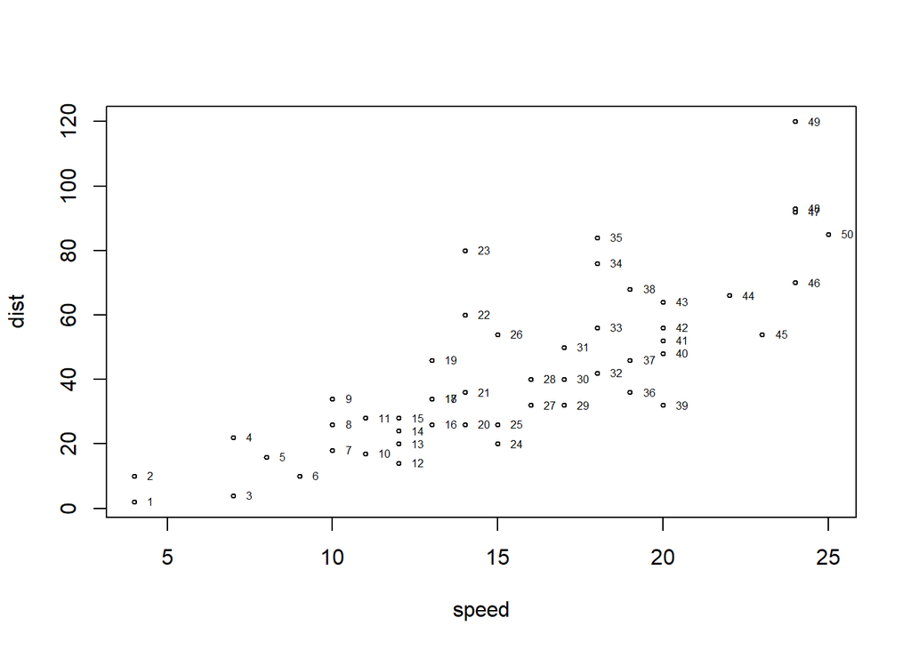

```r
plot(cars, cex=.5)
# text()를 사용하면 점들에 번호를 붙여 각 점이 어느 데이터에 해당하는지 알 수 있다.
# 그러나 데이터가 몰려있는 점에서는 각 점이 어느 데이터에 해당하는지 구분이 어렵다.
text(cars$speed, cars$dist, pos=4, cex=.5)
```

## 1.11 그래프상에 그려진 데이터의 식별

- identify()는 그래프상에서 특정 점을 클릭하면 클릭된 점과 가장 가까운 데이터를 그려준다.
- 그래프 상의 점을 클릭하면 클릭된 점 옆에 각 점이 cars데이터의 몇번째 데이터에 해당하는지 표시되는 것을 볼 수 있다.

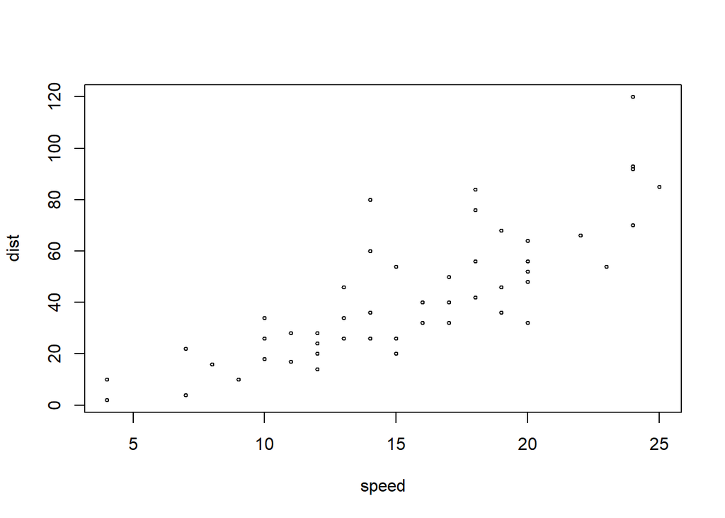

```
## integer(0)
```

```r
plot(cars, cex=.5)
identify(cars$speed, cars$dist)
```

## 1.12 범례(legend)

- legend()는 범례를 표시하는데 사용
- 가장 기본적인 형식은 legend(x, y=NULL, legend)
- 범례가 보여질 (x, y) 좌표를 지정
- 사전에 정의된 키워드(bottomright, bottom, bottomleft, left, topleft, top, topright, right, center) 중 하나로 범례의 위치를 지정

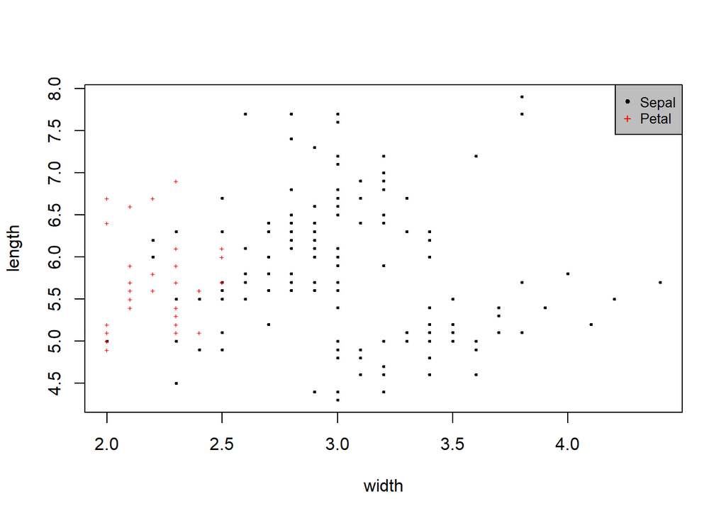

```
한가지 주의할 점은
- Petal을 points()로 그릴때 pch=“+”을 사용했음에도 불구하고 legend에서 pch를 지정할때는 pch=c(20, “+”)가 아니라 pch=c(20, 43)을 사용해야한다는 것이다.
```

```r
plot(
  iris$Sepal.Width,
  iris$Sepal.Length,
  cex=.5,
  pch=20,
  xlab="width",
  ylab="length"
)
points(
  iris$Petal.Width,
  iris$Petal.Length,
  cex=.5,
  pch="+",
  col="#FF0000"
)
legend(
  "topright", # legend()의 위치를 topright
  legend=c("Sepal", "Petal"), # 범례는 Sepal, Petal
  pch=c(20, 43), #  Sepal은 pch 20, Petal은 pch 43(‘+’의 아스키 코드)으로 지정
  cex=.8,
  col=c("black", "red"), # Sepal은 색상 black, Petal은 색상 red로 지정
  bg="gray" # bg는 회색 배경
  )
```

## 1.13 행렬에 저장된 데이터 그리기(matplot, matlines, matpoints)

- matplot(), matlines(), matpoints()는 각각 plot(), lines(), points() 함수와 유사
- 행렬(matrix) 형태로 주어진 데이터를 그래프에 그린다.

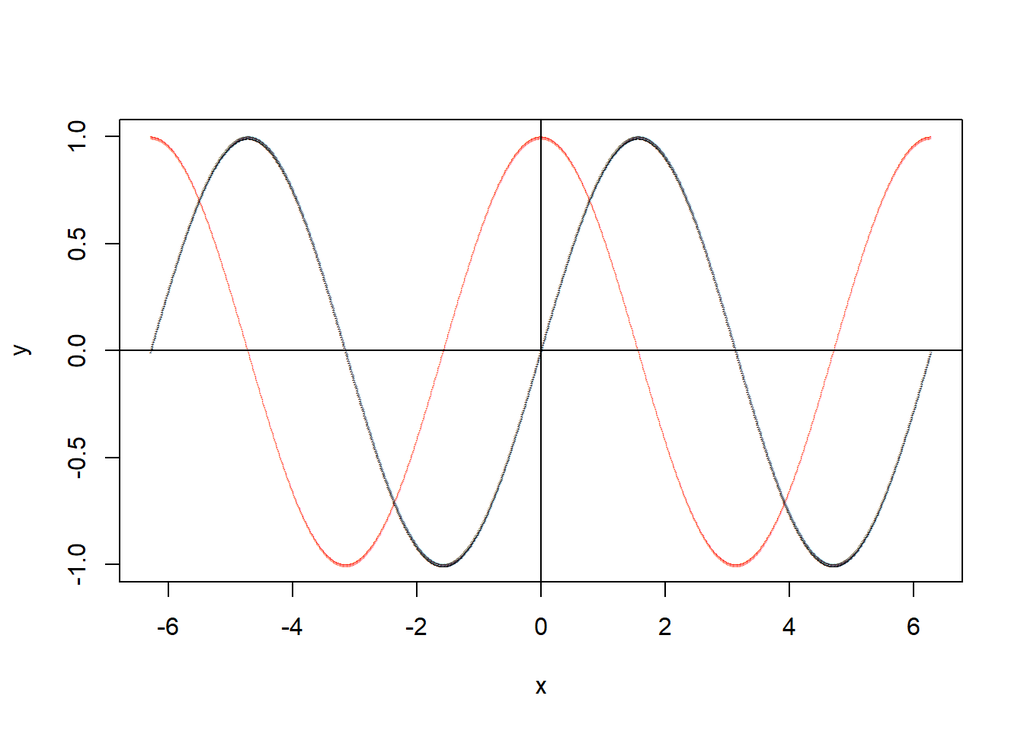

```r
x <- seq(-2*pi, 2*pi, 0.01)
# c(cos(x), sin(x))는 cos(x)로 구해진 벡터와 sin(x)로 구해진 벡터를 합한 새로운 벡터를 만든다.
# matrix()는 값을 열 순으로 채우므로 새로운 벡터는 2개 열을 가진 행렬이 된다.
y <- matrix(c(cos(x), sin(x)), ncol=2) #
# 마지막으로 matplot()으로 그래프를 그리고 x=0, y=0의 두 축을 그려 넣는다.
matplot(x, y, col=c("red", "black"), cex=.2)
abline(h=0, v=0)
```

## 1.14 상자 그림(boxplot)

[output not shown]

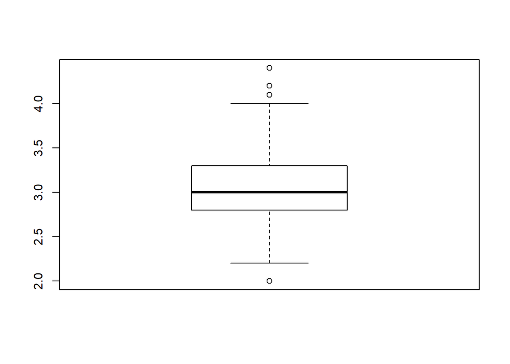

```r
# 제 1사분위수는 약 2.8
# 중앙 값은 약 3.0
# 제 3사분위수는 약 3.3
# Lower whisker는 약 2.2
# lower whisker 보다 작은 outlier 데이터는 1개 발견
# upper whisker는 약 4.0
# upper whisker보다 큰 outlier는 3개
boxplot(iris$Sepal.Width)
```

```r
# 상자 그림을 그리면서 계산된 정확한 값을 보려면 boxplot()의 반환값을 보면 된다.
# ?boxplot의 Value 항목을 보면 boxplot()의 반환값은 리스트로서
# stats은 (lower whisker, 제1사분위수, 중앙값, 제3사분위수, upper whisker)를 갖고있다.
# out은 outlier를 저장하고 있다.
```

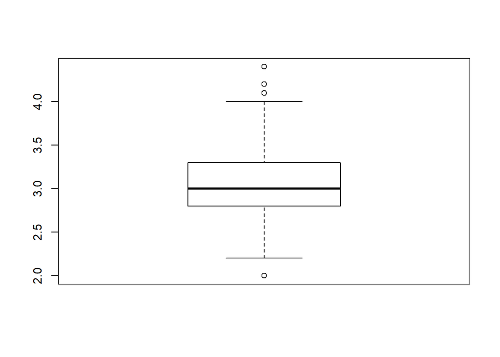

```r
boxstats <- boxplot(iris$Sepal.Width)
```

```r
# lower whisker는 2.2
# 제 1사분위수는 2.8
# 중앙값은  3.0
# 제 3사분위수는 3.3
# upper whisker는 4.0
# outlier는 4.4, 4.1, 4.2, 2.0
boxstats
```

```
## $stats
##      [,1]
## [1,]  2.2
## [2,]  2.8
## [3,]  3.0
## [4,]  3.3
## [5,]  4.0
##
## $n
## [1] 150
##
## $conf
##          [,1]
## [1,] 2.935497
## [2,] 3.064503
##
## $out
## [1] 4.4 4.1 4.2 2.0
##
## $group
## [1] 1 1 1 1
##
## $names
## [1] "1"
```

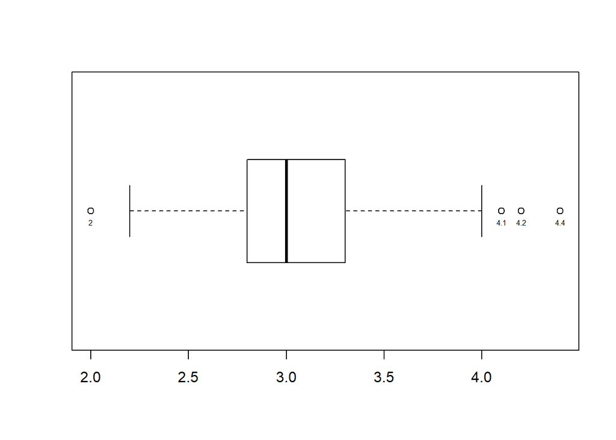

```r
# boxplot() 호출시 지정한 horizontal=TRUE는 상자 그림을 가로로 그리게 한다.
boxstats <- boxplot(iris$Sepal.Width, horizontal = TRUE)
text(
  boxstats$out,
# boxstats$out의 길이가 4이므로 1이 4회 반복된 벡터인 c(1, 1, 1, 1)이 된다
# 텍스트의 위치를 (outlier 값, 1)로 잡은 것이다
  rep(1, NROW(boxstats$out)),
  labels = boxstats$out,
# 텍스트를 점의 하단에 표시
  pos=1,
  cex=.5
)
```

- boxplot()의 notch 인자
- median 값에 대한 신뢰구간이 오목하게 그려진다.
- 2개의 상자 그림을 나란히 그렸을 때 만약 두 상자 그림의 notch가 겹친다면 두 상자 그림의 중앙값이 다르지 않다고 볼 수 있다.
- 만약 겹치지 않는다면 두 상자 그림의 중앙값이 유의하게 다르다고 본다.

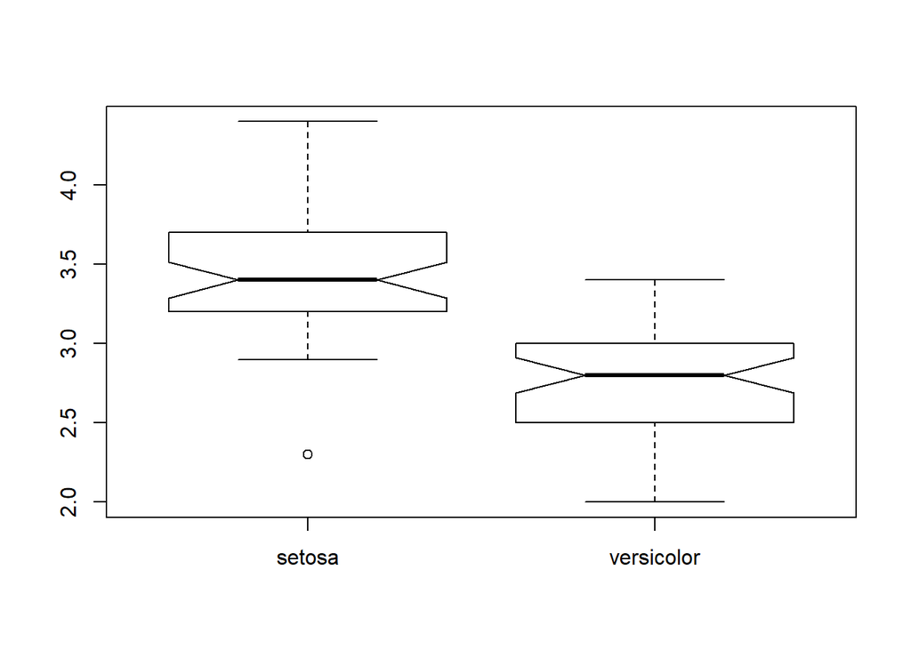

```
 - setosa종의 Sepal.Width가 전반적으로 versicolor종의 Sepal.Width보다 큼을 알 수 있다.
 -  두 상자 그림의 notch를 살펴보자.
 - 상자의 가운데 오목하게 들어간 부분은 각각 setosa와 versicolor의 중앙값에 대한 신뢰구간이다.
 - setosa와 versicolor의 신뢰구간이 겹치지 않으므로 이 두 그룹의 중앙값은 서로 다르다고 결론 내릴 수 있다.
```

```r
# 먼저 iris에서 Species가 setosa 또는 versicolor인 행을 선택
sv <- subset(
  iris,
  Species == "setosa" | Species == "versicolor"
)
# sv$Species를 다시 한번 factor로 변환
# 그 이유는  실제 존재하는 level만 남기고 지우기 위해 다시한번 factor로 변환
# 결과적으로 가로축에 setosa와 versicolor만 나열
# 만약 남아있는 virginica를 없애주지 않으면 텅빈 virginica 컬럼이 추가로 보이게 된다.
sv$Species <- factor(sv$Species)
# Sepal.Width를 Species 마다 그렸다. 이는 'Sepal.Width ∼ Species'로 표현되었다.
boxplot(Sepal.Width ~ Species, data=sv, notch=TRUE)
```

## 1.15 히스토그램(hist)

- 자료의 분포를 알아보는데 유용한 또 다른 그래프
- hist(x)

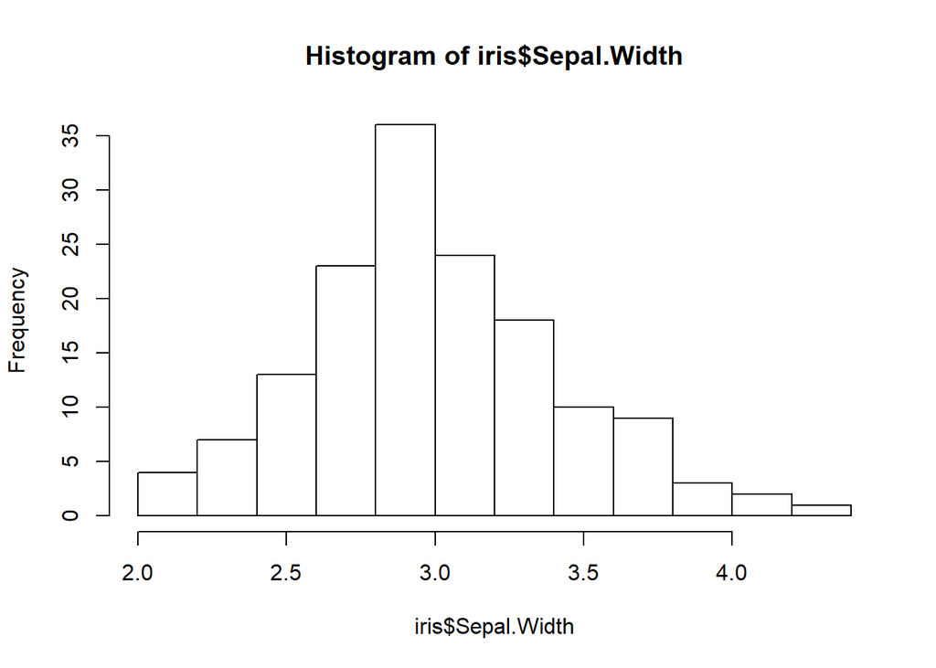

[output not shown]

```r
hist(iris$Sepal.Width)
```

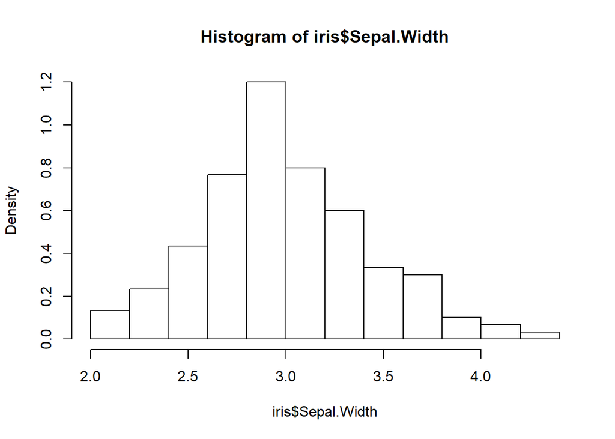

[output not shown]

```r
hist(iris$Sepal.Width, freq=FALSE) # 각 구간의 확률 밀도가 그려진다.
```

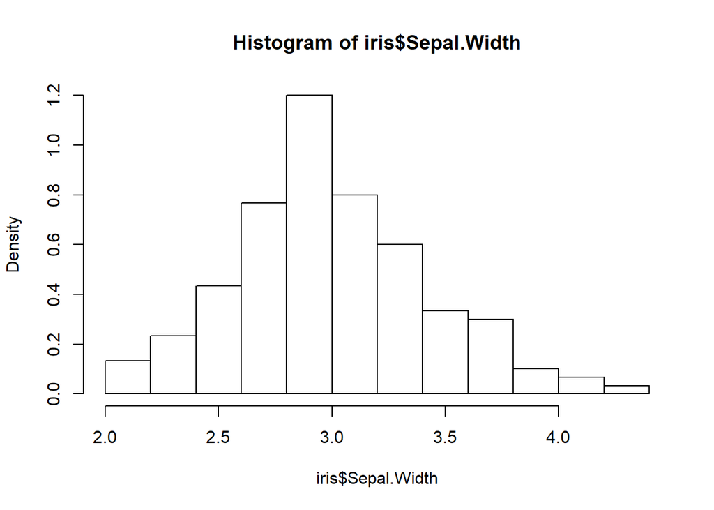

```r
x <- hist(iris$Sepal.Width, freq=FALSE)
```

```r
x
```

```
## $breaks
##  [1] 2.0 2.2 2.4 2.6 2.8 3.0 3.2 3.4 3.6 3.8 4.0 4.2 4.4
##
## $counts
##  [1]  4  7 13 23 36 24 18 10  9  3  2  1
##
## $density
##  [1] 0.13333333 0.23333333 0.43333333 0.76666667 1.20000000 0.80000000
##  [7] 0.60000000 0.33333333 0.30000000 0.10000000 0.06666667 0.03333333
##
## $mids
##  [1] 2.1 2.3 2.5 2.7 2.9 3.1 3.3 3.5 3.7 3.9 4.1 4.3
##
## $xname
## [1] "iris$Sepal.Width"
##
## $equidist
## [1] TRUE
##
## attr(,"class")
## [1] "histogram"
```

```r
sum(x$density) * 0.2
```

```
## [1] 1
```

## 1.16 밀도 그림(density)

- 히스토그램은 분포를 살펴보기위한 가장 잘 알려진 그래프이지만 bin 의 너비를 어떻게 잡는 지에 따라 전혀 다른 모양이 될 수 있다.
- . bin의 경계에서 분포가 확연히 달라지지 않는 kernel density estimation에 의한 밀도 그림이다.
- 밀도 그림은 density() 함수를 사용한다.

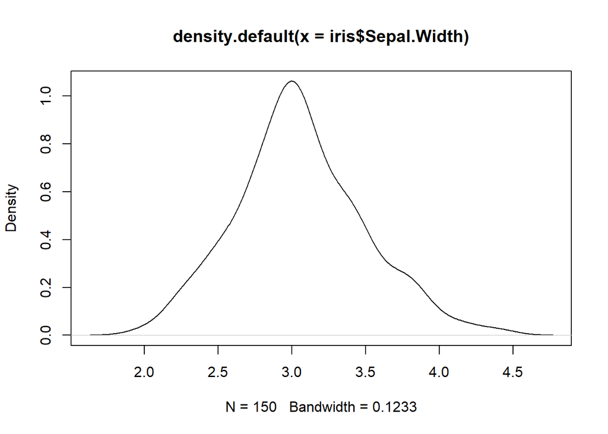

```r
plot(density(iris$Sepal.Width))
```

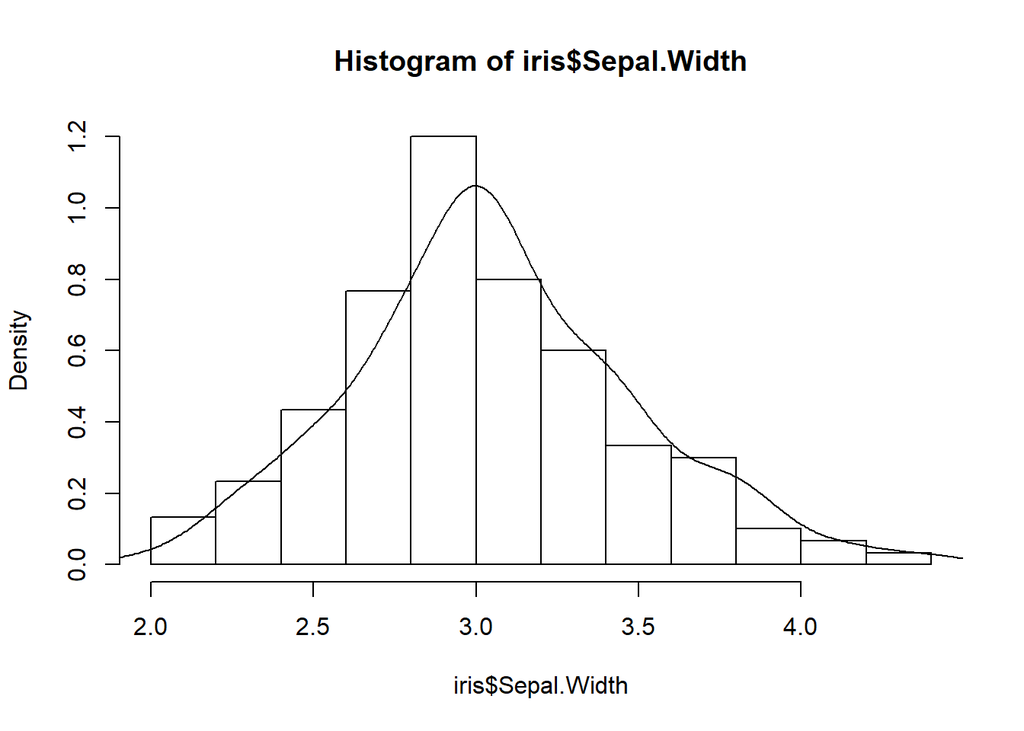

```r
# 밀도그림은 히스토그램과 같이 그릴 수도 있다.
hist(iris$Sepal.Width, freq=FALSE)
lines(density(iris$Sepal.Width))
```

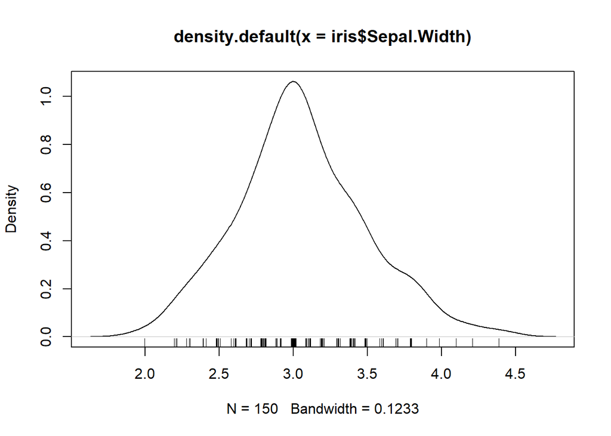

```r
# 밀도 그림에 rug() 함수를 사용해 실제 데이터의 위치를 표시할 수 있다.
# 이때, 데이터가 중첩되는 경우가 많다면 jitter()를 같이 사용한다.
plot(density(iris$Sepal.Width))
rug(jitter(iris$Sepal.Width))
```

## 1.17 막대 그림(barplot)

- barplot() 함수

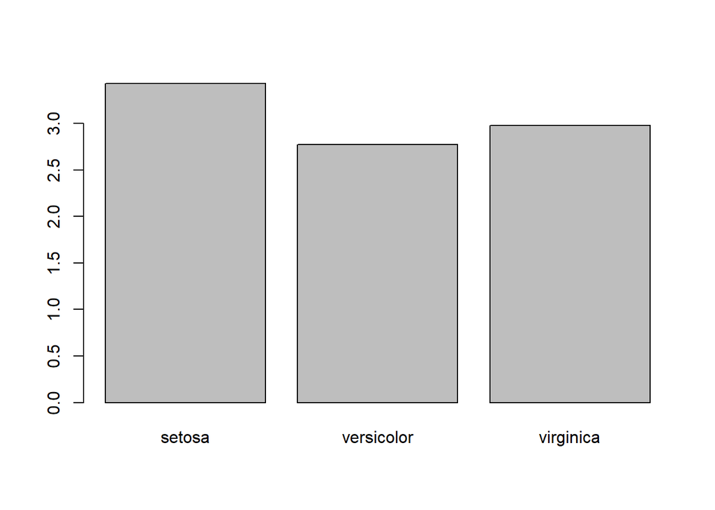

```r
barplot(
  tapply(
    iris$Sepal.Width, # 데이터
    iris$Species, # 그룹 인덱스
    mean # 각 그룹별로 호출할 함수
  )
)
```

## 1.18 파이 그래프(pie)

- 파이 그래프는 pie() 함수를 사용
- 데이터의 비율을 알아보는데 적합

> Sepal.Length의 구간별 비율을 파이 그래프로 그려보기 - 구간으로 데이터를 나누기 위해서 cut() 함수를 사용 - cut()은 인자로써 구간으로 나눌 데이터와 breaks를 받는다. - breaks에는 나눌 구간을 직접 넘겨도 되고 나눌 구간의 수를 넘겨도 된다.

```r
# (0, 5]는 0 < x ≤ 5 의 형태이므로 breaks의 값을 c(1, 5, 10)으로 지정해서는 안된다.
# 이 경우 1이 어떤 구간에도 속하지 않게 되기 때문이다 .
cut(1:10, breaks= c(0, 5, 10))
```

```
##  [1] (0,5]  (0,5]  (0,5]  (0,5]  (0,5]  (5,10] (5,10] (5,10] (5,10] (5,10]
## Levels: (0,5] (5,10]
```

```r
# 1부터 10까지의 수를 3개의 구간으로 나누는 예
cut(1:10, breaks= 3)
```

```
##  [1] (0.991,4] (0.991,4] (0.991,4] (0.991,4] (4,7]     (4,7]     (4,7]
##  [8] (7,10]    (7,10]    (7,10]
## Levels: (0.991,4] (4,7] (7,10]
```

```r
# 구간의 수를 지정하면 동일한 너비의 구간이 자동으로 구해진다.
cut(iris$Sepal.Width, breaks = 10)
```

```
##   [1] (3.44,3.68] (2.96,3.2]  (2.96,3.2]  (2.96,3.2]  (3.44,3.68]
##   [6] (3.68,3.92] (3.2,3.44]  (3.2,3.44]  (2.72,2.96] (2.96,3.2]
##  [11] (3.68,3.92] (3.2,3.44]  (2.96,3.2]  (2.96,3.2]  (3.92,4.16]
##  [16] (4.16,4.4]  (3.68,3.92] (3.44,3.68] (3.68,3.92] (3.68,3.92]
##  [21] (3.2,3.44]  (3.68,3.92] (3.44,3.68] (3.2,3.44]  (3.2,3.44]
##  [26] (2.96,3.2]  (3.2,3.44]  (3.44,3.68] (3.2,3.44]  (2.96,3.2]
##  [31] (2.96,3.2]  (3.2,3.44]  (3.92,4.16] (4.16,4.4]  (2.96,3.2]
##  [36] (2.96,3.2]  (3.44,3.68] (3.44,3.68] (2.96,3.2]  (3.2,3.44]
##  [41] (3.44,3.68] (2.24,2.48] (2.96,3.2]  (3.44,3.68] (3.68,3.92]
##  [46] (2.96,3.2]  (3.68,3.92] (2.96,3.2]  (3.68,3.92] (3.2,3.44]
##  [51] (2.96,3.2]  (2.96,3.2]  (2.96,3.2]  (2.24,2.48] (2.72,2.96]
##  [56] (2.72,2.96] (3.2,3.44]  (2.24,2.48] (2.72,2.96] (2.48,2.72]
##  [61] (2,2.24]    (2.96,3.2]  (2,2.24]    (2.72,2.96] (2.72,2.96]
##  [66] (2.96,3.2]  (2.96,3.2]  (2.48,2.72] (2,2.24]    (2.48,2.72]
##  [71] (2.96,3.2]  (2.72,2.96] (2.48,2.72] (2.72,2.96] (2.72,2.96]
```

[output cut: 16 more lines]

```
  - 파이 그래프를 그리려면 이 factor 데이터를 그대로 사용할 수는 없다.
  - 나눠진 각 구간에 몇 개의 데이터가 있는지 세어야 한다.
  - table()함수는 이러한 목적으로 사용된다.
  - factor 값을 받아 분할표(Contingency Table. Cross Tabulation 또는 Cross Tab이라고도 부른다.)를 만든다.
```

```r
rep(c("a", "b", "c"), 1:3)
```

```
## [1] "a" "b" "b" "c" "c" "c"
```

```r
table(rep(c("a", "b", "c"), 1:3))
```

```
##
## a b c
## 1 2 3
```

```r
# table() 함수의 결과로 각 문자의 갯수가 구해졌음을 볼 수 있다.
table(cut(iris$Sepal.Width, breaks=10))
```

```
##
##    (2,2.24] (2.24,2.48] (2.48,2.72] (2.72,2.96]  (2.96,3.2]  (3.2,3.44]
##           4           7          22          24          50          18
## (3.44,3.68] (3.68,3.92] (3.92,4.16]  (4.16,4.4]
##          10          11           2           2
```

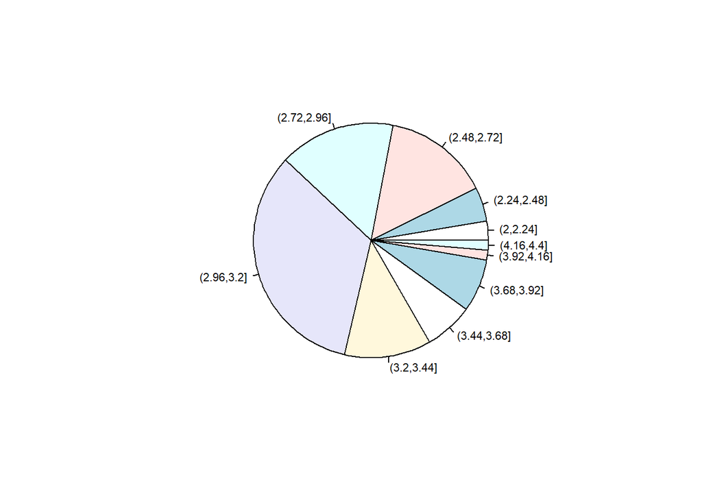

```r
pie(
  table(
    cut(iris$Sepal.Width, breaks=10)
  ),
  cex=.7
)
```

## 1.19 모자이크 플롯(mosaicplot)

- 범주형 다변량 데이터를 표현하는데 적합한 그래프로 mosaicplot() 함수를 사용해 그린다.
- 모자이크 플롯에는 사각형들이 그래프에 나열되며, 각 사각형의 넓이가 각 범주에 속한 데이터의 수에 해당된다.

```r
str(Titanic)
```

```
##  table [1:4, 1:2, 1:2, 1:2] 0 0 35 0 0 0 17 0 118 154 ...
##  - attr(*, "dimnames")=List of 4
##   ..$ Class   : chr [1:4] "1st" "2nd" "3rd" "Crew"
##   ..$ Sex     : chr [1:2] "Male" "Female"
##   ..$ Age     : chr [1:2] "Child" "Adult"
##   ..$ Survived: chr [1:2] "No" "Yes"
```

```r
# Titanic은 table 클래스의 인스턴스이며 속성은 객실 구분(Class), 성별(Sex), 성인여부(Adult), 생존 여부(Survived)로 구성되어 있다.
Titanic
```

```
## , , Age = Child, Survived = No
##
##       Sex
## Class  Male Female
##   1st     0      0
##   2nd     0      0
##   3rd    35     17
##   Crew    0      0
##
## , , Age = Adult, Survived = No
##
##       Sex
## Class  Male Female
##   1st   118      4
##   2nd   154     13
##   3rd   387     89
##   Crew  670      3
##
## , , Age = Child, Survived = Yes
##
##       Sex
## Class  Male Female
##   1st     5      1
##   2nd    11     13
##   3rd    13     14
##   Crew    0      0
##
## , , Age = Adult, Survived = Yes
##
##       Sex
## Class  Male Female
##   1st    57    140
##   2nd    14     80
##   3rd    75     76
##   Crew  192     20
```

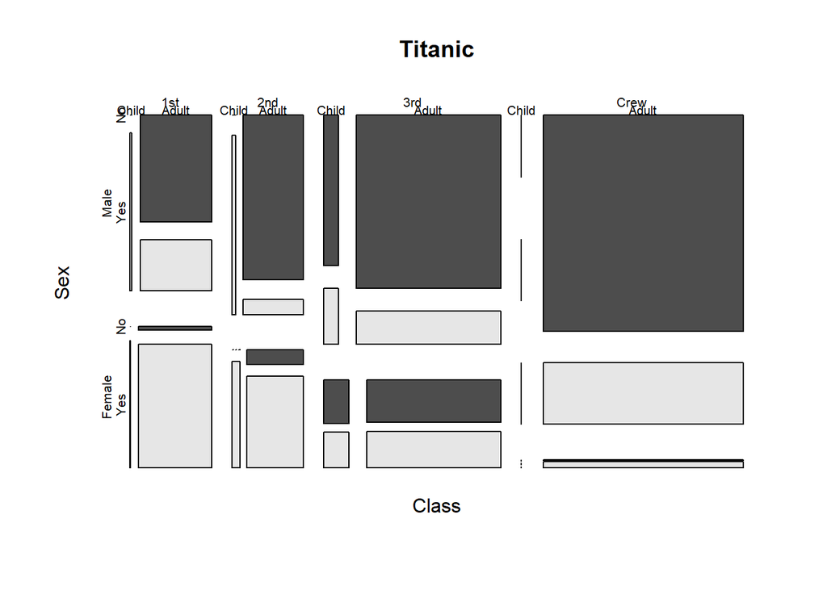

```r
mosaicplot(Titanic, color=TRUE)
```

-성별이 남성(Male)인 경우 1등석(1st) 성인(Adult)의 사망률은 같은 그룹에서의 생존률보다 높음을 알 수 있다. - 일부 속성에 대해서만 살펴보려면 ‘mosaicplot(formula, data)’ 의 형태를 사용할 수 있다.

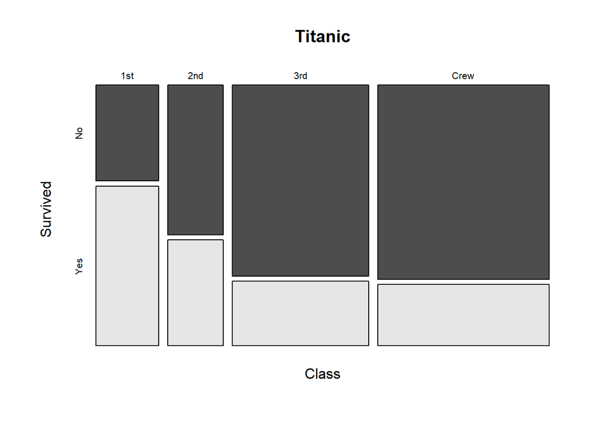

```r
# 객실(Class)과 생존(Survived)여부에 대한 모자이크 플롯
mosaicplot(~ Class + Survived, data=Titanic, color=TRUE)
```

- 높은 등급 객실에서의 생존률이 낮은 등급 객실에서의 생존률 보다 높음을 더 쉽게 알 수 있다.

## 1.20 산점도 행렬(pairs)

- 산점도 행렬(Scatter Plot Matrix)은 다변량 데이터에서 변수 쌍간의 산점도 행렬을 그린 그래프
- 산점도 행렬은 pairs() 함수를 이용

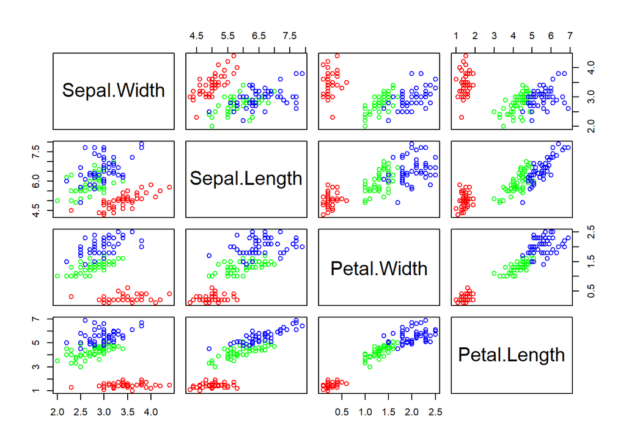

```r
pairs(
  ~ Sepal.Width + Sepal.Length + Petal.Width + Petal.Length,
  data=iris,
  col=c("red", "green", "blue")[iris$Species]
)
```

- setosa는 빨간색, versicolor는 녹색, virginica는 파란색으로 표시 - levels()로 범주의 목록을 통해 확인 - setosa가 1, versicolor가 2, virginica가 3에 해당하여 “red”, “green”, “blue”사용

```r
levels(iris$Species)
```

```
## [1] "setosa"     "versicolor" "virginica"
```

```r
as.numeric(iris$Species)
```

```
##   [1] 1 1 1 1 1 1 1 1 1 1 1 1 1 1 1 1 1 1 1 1 1 1 1 1 1 1 1 1 1 1 1 1 1 1 1
##  [36] 1 1 1 1 1 1 1 1 1 1 1 1 1 1 1 2 2 2 2 2 2 2 2 2 2 2 2 2 2 2 2 2 2 2 2
##  [71] 2 2 2 2 2 2 2 2 2 2 2 2 2 2 2 2 2 2 2 2 2 2 2 2 2 2 2 2 2 2 3 3 3 3 3
## [106] 3 3 3 3 3 3 3 3 3 3 3 3 3 3 3 3 3 3 3 3 3 3 3 3 3 3 3 3 3 3 3 3 3 3 3
## [141] 3 3 3 3 3 3 3 3 3 3
```

- as.numeric()은 Factor를 숫자형 벡터로 바꾸는 함수
- Factor 레벨의 순서에 따라 숫자값을 반환

## 1.21 투시도(persp), 등고선 그래프(contour)

- 투시도는 3차원 데이터를 마치 투시한 것처럼 그린 그림
- persp()함수 사용
- persp()는 인자로 X그리드, Y그리드, 그리고 각 grid 점에서의 Z값을 인자로 받는다.
- outer(X, Y, FUN)의 FUN은 각 X, Y조합에 대해 수행할 함수

```r
outer(1:5, 1:3, "+")
```

```
##      [,1] [,2] [,3]
## [1,]    2    3    4
## [2,]    3    4    5
## [3,]    4    5    6
## [4,]    5    6    7
## [5,]    6    7    8
```

```r
#  outer()의 결과는 5행 3열의 행렬로서 (x, y)에는 x+y가 각각 저장되어 있음
outer(1:5, 1:3, function(x, y) { x + y })
```

```
##      [,1] [,2] [,3]
## [1,]    2    3    4
## [2,]    3    4    5
## [3,]    4    5    6
## [4,]    5    6    7
## [5,]    6    7    8
```

```
 - outer()를 사용해 X축 그리드 seq(-3, 3, .1), Y축 그리드 seq(-3, 3, .1) 에 대해
이변량 정규분포(bivariate normal distribution)를 그려보자.
 - persp()에 넘길 Z인자는 각 X, Y 그리드점에 대해 확률 밀도인데, 다변량 정규분포(multivariate normal distribution)의 확률밀도는 dmvnorm() 을 사용해 계산한다.
```

```r
# install.packages("mvtnorm")
library(mvtnorm)
dmvnorm( c(0, 0), rep(0, 2), diag(2) )
```

```
## [1] 0.1591549
```

- seq(-3, 3, .1)의 X, Y축 그리드 조합에 대해 Z축 값을 구한다.
- dmvnorm() 에서 평균의 기본값은 영행렬(zero matrix)이고, 공분산 행렬의 기본값은 단위행렬이다.

```r
x <- seq(-3, 3, .1)
y <- x
outer(x, y, function(x, y) { dmvnorm(cbind(x, y))})
```

[output not shown]

[output cut: 791 more lines]

> 투시도

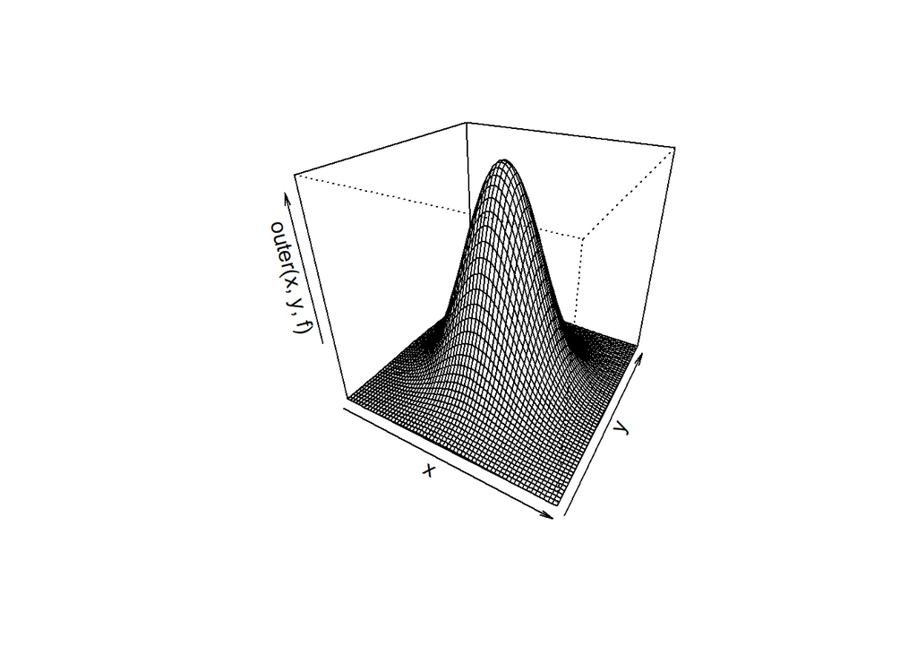

```r
x <- seq(-3, 3, .1)
y <- x
f <- function(x, y) { dmvnorm(cbind(x, y))}
persp(x, y, outer(x, y, f), theta = 30, phi = 30) # theta와 phi는 그림의 기울어진 각도를 지정하는 인자
```

- 등고선 그래프는 투시도와 유사하지만 투시한 3차원 그림대신 값이 같은 곳들을 선으로 연결한 등고선을 이용해 데이터를 표시
- 등고선 그래프는 contour()를 사용해 그린다.
- 인자는 persp()를 그릴 때와 마찬가지의 데이터를 사용

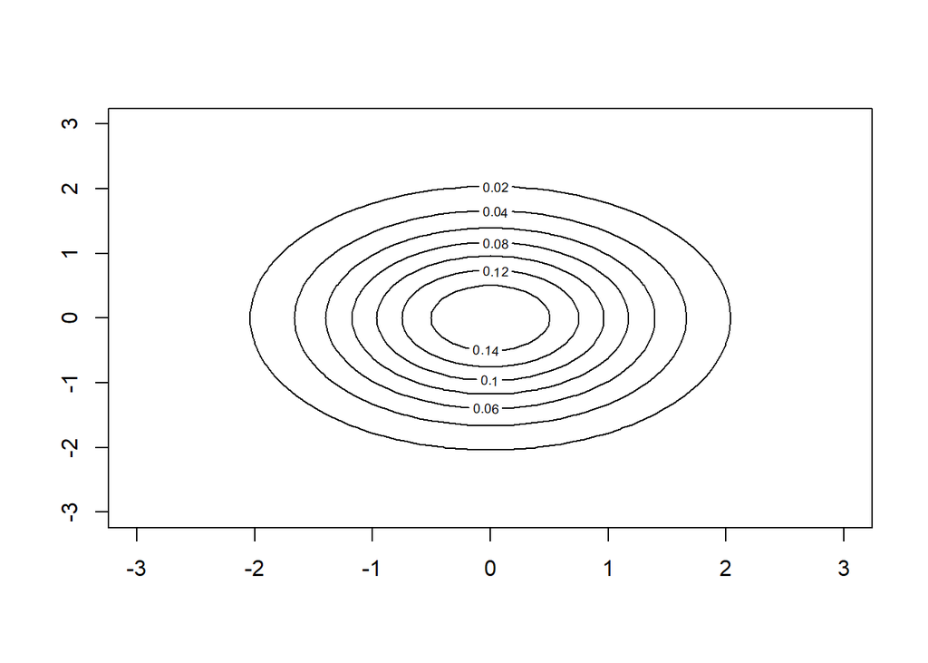

```r
contour(x, y, outer(x, y, f))
```